# Weekly Arrangements

Published

September 17, 2023

# Preface: How to Use This Guide

## Arrangements each week

We will have a 3-hour session each week and I will aim to cover a new marketing analytics model. Whenever we learn a new technique (e.g., a new statistical model or a new analytics tool), the subsequent week will often start with some warm-up exercise and a seminar workshop (with a case study) for you to review and practice the new technique learned in the previous week. This way, you would have time to digest what you’ve learned and can further reflect on your understanding of the technique by practicing your skills with a real-life application.

For instance, in week 1, I will first introduce the concepts of marketing and marketing process, and then will cover the concept of customer lifetime value (CLV) and how to compute CLV with R. In week 2, we will therefore begin with a case study that helps you practice your knowledge of CLV, so you can understand how to use CLV for better marketing decisions in your future projects/jobs.

In the remaining time of week 2, I will then introduce a new technique: the `dplyr` package in R, which helps us clean and manipulate datasets in R. Following a similar logic, then in week 3, we will start with a case study for you to practice the `dplyr` package. So on and so forth.

## About the labels

- Essential: contents core to this week’s materials. All pre-class preparations should be completed before class.
- Optional: supplemental readings for those interested in learning more

## Module Outline

Module Outline

| Week | Substantive Topic | Methodology Topic | Case Study |
| --- | --- | --- | --- |
| Induction Week |  | Basics of R |  |
| 1 | Module Introduction and Profitability Analysis | Arithmetic computation with R | Profitability Analysis for PineApple Inc. |
| 2 | Customer Lifetime Value | Data wrangling with R | Customer Lifetime Value |
| 3 | Preliminary customer analysis | Unsupervised learning | Preliminary Customer Analysis |
| 4 1st assignment due | Customer segmentation | Supervised learning | Improving Marketing Efficiency for Tesco with Predictive Analytics I (Unsupervised Learning) |
| 5 | Causal Inference |  | Improving Marketing Efficiency with Predictive Analytics II (Supervised Learning) |
| 6 | Promotion Analytics | Rubin Causal Model, Potential Outcome Framework, and A/B testing |  |
| 7 | Marketing Mix Modeling | Linear Regression and ordinary least square | Improve User Engagement on Social Media Platforms using A/B Testing |
| 8 2nd assignment due | Platform Design | Instrumental variable and two-stage least square |  |
| 9 | Privacy regulation and market design | Quasi-experiments |  |
| 10 | Personalized treatment effect | Causal machine learning |  |
| 3rd assignment due |  |  |  |

# Induction Week: R Basics

**Pre-class preparation**

- Install R, RStudio, and Quarto following the [guide](https://weim-mkt.github.io/UCLMarketingAnalytics/R-installR.html).
- Finish reading “An introduction to R” (can be assessed in this [link](https://cran.r-project.org/doc/manuals/r-release/R-intro.pdf)) Chapters 1, 2, and 3. Please try to practice the codes in R along your reading. Take a note of any questions you may have during your self-study. I will cover R basics in greater details in the induction week.
- What you will learn
  - An introduction to R basics
- After-class exercise
  - (essential) Finish the after-class exercise. We will learn how to use R to compute customer lifetime value next week, so it’s very important that you are familiar with R basics before class.

# Week 1: Module Introduction and Customer Lifetime Value

**Pre-class Preparation**

- Remember to bring your laptop to class **each week**, as we will be practicing R programming in class every week; make sure you have installed R and RStudio following the [installation guide](https://weim-mkt.github.io/UCLMarketingAnalytics/R-installR.html)
- Complete the R exercise on the `Case-BreakEvenAnalysis-Stu.qmd`. You can find the file on Moodle.

## Module Introduction

- What you will learn
  - An overview of the course topics and requirements
  - Concept of marketing and marketing process
  - How marketing analytics can empower marketers in the digital era
- After-class reading
  - (optional) [The Definitive Guide to Strategic Marketing Planning](https://www.smartsheet.com/strategic-marketing-processes-and-planning). Highly recommended if you didn’t take marketing undergrad courses and would like to know more about the conventional marketing process.

## Customer Profitability and Lifetime Value

- What you will learn
  - How to conduct break-even analyses (static and dynamic)
  - The concept of customer life cycle
  - How to compute customer acquisition cost (CAC)
  - How to compute customer lifetime value (CLV)
- After-class reading
  - (optional) [“Hubspot: How to compute CLV”](https://blog.hubspot.com/service/how-to-calculate-customer-lifetime-value). This article introduces alternative ways to compute CLV, which are used in many companies.
  - (optional) [“Important lessons for embracing customer lifetime value”](https://www.thinkwithgoogle.com/intl/en-gb/marketing-strategies/data-and-measurement/marketing-customer-lifetime-value-clv/)
  - (essential) [“Common R Programming Errors Faced by Beginners”](https://weim-mkt.github.io/UCLMarketingAnalytics/R-errors.html). This guide will be updated constantly and summarizes the common R errors you may encounter as beginners. For any questions, come here first for solutions.

# Week 2: Data Wrangling with R

## Case Study: Customer Lifetime Social Value

**Pre-class preparation**

- HBS 9-518-077: Customer Lifetime Social Value (CLSV).
  - In the first class this week, we will go through how to compute the customer lifetime value for i-basket, a US grocery supermarket, in this case study. We will only focus on the CLV calculation part while leaving CLSV as after-class optional learning contents. **Please read pages 1-8. Pages 1-5 introduce the case background; pages 5-8 introduce key information to compute CLV for the company.**
  - When reading the case, please use the mind map below to find out all key information, including the variable, the value, and where it shows up in the case study. Highlight them on the PDF. This can help you quickly find that information in class.
  - Think about the following questions, which we will discuss in class.
    1. What would be the time unit of analyses? monthly or yearly? How many years of customer’s lifetime to consider for CLV calculation? Is this reasonable?
    2. What is the information needed to calculate the net cash flows of a customer in each period? Where can you find the M and c in the CLV formula? Highlight these key numbers so that we can create them in R directly.
    3. How do we incorporate customer churn in CLV calculation?
    4. What are the costs i-basket needs to incur to acquire a customer? Based on this information, how to compute the customer acquisition costs (CAC)?
    5. Can you figure out how to compute CLV with R even before Wednesday class? You can try your best to use what we have learned in Week 1 to compute the CLV for i-basket on your own. The exercise Quarto file is already given below.

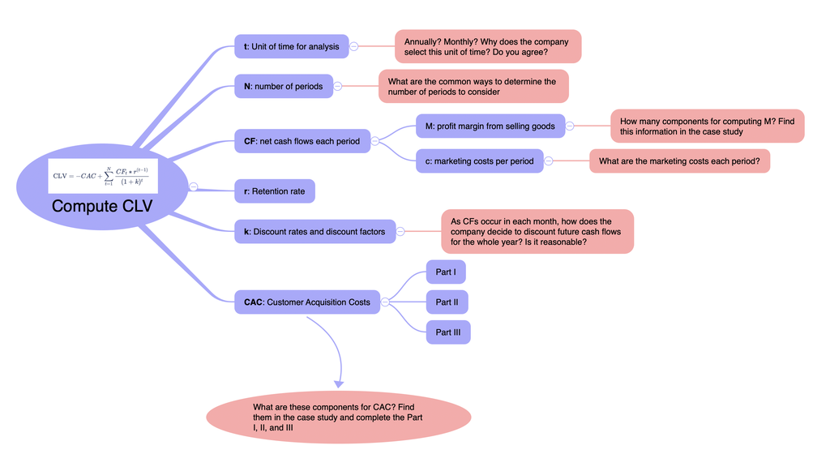

Mindmap for Computing the CLV for i-basket

- What you will learn
  - How to apply CLV calculation in a real-life case study
  - Discuss how CLV can be used by marketers to guide marketing decisions
- After-class reading
  - (optional) [The Dangerous Seduction of the Lifetime Value (LTV) Formula](https://abovethecrowd.com/2012/09/04/the-dangerous-seduction-of-the-lifetime-value-ltv-formula/)

## Data Wrangling with R: Part I

- What you will learn
  - Process of a typical data analytics task
  - How to use `filter`, `mutate`, and `arrange` for data manipulation with `dplyr` package in R
- After-class reading
  - (essential) Finish the practice exercise on data camp: [Data Manipulation with dplyr: 1.Transforming Data with dplyr](https://app.datacamp.com/learn/courses/data-manipulation-with-dplyr)
  - (essential) [Cheatsheet for `dplyr`](https://www.rstudio.com/wp-content/uploads/2015/02/data-wrangling-cheatsheet.pdf)
  - (optional) [Python Pandas vs. R Dplyr](https://towardsdatascience.com/python-pandas-vs-r-dplyr-5b5081945ccb). In David’s class, you will learn how to use Python Pandas for data wrangling in the last two weeks. This cheat sheet provides a one-to-one comparison of the two libraries for your reference.

# Week 3: Predictive Analytics for Customer Segmentation

## Data Wrangling with R: Part II

**Pre-class preparation**

- Before Wednesday class, please finish the following
  - read the 2 case studies; please familiarize yourself with the variable definitions. **This is very important** as we will use the two datasets to learn data wrangling in R using the dplyr package.
  - open the two datasets (demographics.csv and purchase.csv) in Excel and inspect the data sets, especially the data structure (what each row means and what each column means)
- There is no pre-class coding exercise required for this week. We will be doing data wrangling together in class to solve case questions.
- What you will learn
  - The usage of `group_by` and `join` for data aggregation and merge with `dplyr` package
  - How to use `dplyr` to conduct preliminary customer analyses
- After-class reading
  - (essential) Finish the practice exercise on data camp: [Data Manipulation with dplyr: 2.Aggregating Data](https://app.datacamp.com/learn/courses/data-manipulation-with-dplyr)
  - (optional) Go through the [tutorial](https://vincentarelbundock.github.io/modelsummary/articles/datasummary.html) of `modelsummary` package to learn more features

## Predictive Analytics: Unsupervised Learning

- What you will learn
  - Important concepts in predictive analytics
  - Concept of unsupervised learning
  - How to run K-means clustering in R
- After-class reading
  - (recommended) [K-means Cluster Analysis](https://uc-r.github.io/kmeans_clustering), which provides more details on the maths behind the K-means clustering

# Week 4: Predictive Analytics for Customer Targeting

## Supervised Learning Basics

- What you will learn
  - Definition of supervised learning
  - Types of supervised learning
  - Fundamental tradeoffs in supervised learning
  - Overfitting and underfitting issues and how to overcome them
- After-class reading
  - (optional) [Varian, Hal R. “Big data: New tricks for econometrics.” Journal of Economic Perspectives 28, no. 2 (2014): 3-28](https://ucl.primo.exlibrisgroup.com/permalink/44UCL_INST/18kagqf/cdi_proquest_miscellaneous_1541646040)

## Tree-based Models and Their Application to Targeted Marketing

- What you will learn
  - Intuition behind decision tree and random forest models
  - How to build random forest models in R
  - The application predictive analytics (supervised learning) in targeted marketing
- After-class reading
  - (recommended) [Decision tree in R](http://uc-r.github.io/regression_trees) and [Random forest in R](http://uc-r.github.io/random_forests). Both tutorials introduce the detailed maths behind the two models if you would like to learn more
  - (optional) [Available machine learning model packages in R](https://cran.r-project.org/web/views/MachineLearning.html). In class, we have learned how to use R packages to run random forest models. This link lists all other machine learning packages that can be used in R. You can learn how to use these models following their manuals.

# Week 5: Causal Inference and RCT

## Case Study: Improve Marketing Efficiency for Tesco Using Supervised Learning

**Pre-class preparation**

- Case Study: Improving Marketing Efficiency Using Targeted Marketing
  - Please carefully read the case background before class, especially review the definitions of Response.
- What you will learn
  - How to apply predictive analytics (supervised learning models) to help Tesco improve its marketing efficiency

## Causal Inference and A/B Testing

**Pre-class preparation**

- This and next week, we will be conducting t-tests with R in class to estimate treatment effects from randomized experiments. If you’re unfamiliar with t-tests, please go through this [Review of Statistics with R](https://www.econometrics-with-r.org/3-arosur.html) before the next week’s class.
- What you will learn
  - Concept of causal inference
  - Concept of Rubin’s potential outcome framework and treatment effects
  - Why RCT is the gold standard of causal inference
- After-class reading
  - (optional) [Varian, Hal R. ‘Causal Inference in Economics and Marketing’. Proceedings of the National Academy of Sciences 113, no. 27 (5 July 2016): 7310–15.](https://ucl.primo.exlibrisgroup.com/permalink/44UCL_INST/18kagqf/cdi_pubmedcentral_primary_oai_pubmedcentral_nih_gov_4941501)

# Week 6: Linear Regression

## Workshop: Improve User Engagement on Social Media Platforms Using A/B Testings

**Pre-class preparation**

- Case study: Improve User Engagement on Social Media Platforms Using A/B Testings. Please carefully read the case background before class; we will be discussing the case in class
  - Conduct a 5C situation analysis for Twitter
- What you will learn
  - Steps to design and conduct an RCT (A/B testing)
  - The business model of social media platforms
  - Design A/B testing to solve real-life marketing problems
- After-class reading
  - (recommended) [Test and learn: How a culture of experimentation can help grow your business](https://www.thinkwithgoogle.com/intl/en-gb/marketing-strategies/data-and-measurement/test-learn-experiment-culture/)
  - (optional) [A Comparison of Approaches to Advertising Measurement: Evidence from Big Field Experiments at Facebook](https://www.kellogg.northwestern.edu/faculty/gordon_b/files/kellogg_fb_whitepaper.pdf)

## Linear Regression Models

- What you will learn
  - Review of concept for Data Generating Process (DGP) and a model
  - The intuition behind coefficient estimation of linear regression models
  - How to run linear regression models in R
  - How to interpret the regression coefficients and statistics
- After-class reading
  - (highly recommended) [Introduction to Econometrics with R](https://www.econometrics-with-r.org/index.html), Chapters 4-7. These 4 chapters cover very detailed applied knowledge of linear regressions. Due to limited time, we cannot cover all contents in class, so it would be great if you can take time to go through these chapters thoroughly.

# Week 7: Marketing Mix Modeling

## Linear Regression Model: Advanced Topics

- What you will learn
  - How to model non-linear relationship using linear regression
  - How to interpret the coefficients of categorical variables

## Marketing Mix Modelling with Linear Regression

- What you will learn
  - How to build linear regression-based marketing mix models to solve pricing and promotion optimization problems
- After-class reading
  - [A complete guide to Marketing Mix Modeling](https://www.latentview.com/marketing-mix-modeling/)

# Week 8: Endogeneity and Instrumental Variables

**Pre-class preparation**

- Case Study: The Causal Impact of COVID-19 on Ridesharing
  - Please carefully read the case background before class and we will be discussing the case in class.
  - Finish the coding exercise in the Quarto document before Section 4 IV regression (similar questions will be in the last assignment).

## Endogeneity

- What you will learn
  - Endogeneity and its consequences in causal inference
  - The causes of endogeneity including omitted variable bias, reverse causality, and measurement error

## Instrumental Variables

- What you will learn
  - Intuition of why instrumental variables solve endogeneity problems
  - The two requirements of a valid instrumental variable and how to find good instruments
  - Apply two-stage least square method to estimate the causal effects using instrumental variables
  - Application of instrumental variables in the marketing and business field
- After-class reading
  - (optional) [Econometrics with R: Instrumental Variables Regression](https://www.econometrics-with-r.org/12-ivr.html)
  - (highly recommended) Encouragement Designs and Instrumental Variables for A/B Testing at Spotify

# Week 9: Quasi-Experimental Methods

## Regression Discontinuity Design

- What you will learn
  - Concept of regression discontinuity design (RDD)
  - Estimation of causal effects using the RDD design
  - Application of RDD designs in the business field

## Difference-in-Differences Design

- What you will learn
  - Concept of difference-in-differences (DiD) design
  - Estimation of causal effects using the DiD design
  - Application of DiD design in the business field
- After-class reading
  - (optional) [Econometrics with R: Quasi-experiments](https://www.econometrics-with-r.org/13.4-qe.html)

# Week 10: Frontiers of Marketing Analytics

## Frontiers of Marketing Analytics

- What you will learn
  - Causal machine learning with causal forest
  - Heterogeneous treatment effect estimation with causal forest in R
- After-class reading
  - [Estimate causal effects using ML](https://www.microsoft.com/en-us/research/project/econml/) by Microsoft Research
  - Athey, Susan, and Stefan Wager. ‘Estimating Treatment Effects with Causal Forests: An Application’. ArXiv:1902.07409 [Stat], 20 February 2019. http://arxiv.org/abs/1902.07409.